# ex00_introduction slides

### Getting started with pyaerocom

This notebook is meant to give a quick introduction into the main features and workflows of [pyaerocom](http://aerocom.met.no/pyaerocom/).

This includes brief introductions into the following features:

- Finding model and observation data on the AeroCom servers (method `browse_database`).
- Reading of *gridded* model data (`ReadGridded` class).
- Reading of *ungridded* observation data (`ReadUngridded` class).
- Working with *gridded* data (`GriddedData` class).
- Working with *ungridded* data (`UngriddedData` class).
- Retrieving and working with data from individual stations (`StationData` class).
- *Colocation* of model data with all stations from an observation network.

It ends with a colocation of CAM53-Oslo model AODs both all-sky and clear-sky with Aeronet Sun V3 level 2 data.

#### Prerequisites

- In order to run this notebook, you need to be connected to the AeroCom post processing servers (PPI).
- If you have PPI (/lustre/) mounted on your local machine you need to update the basic data directory after importing pyaerocom as follows:

  ```
   import pyaerocom as pya
   pya.const.BASEDIR = '<dir_where_lustre_is_mounted>/lustre/storeA/project/aerocom'
  ```

#### Pyaerocom API flowchart

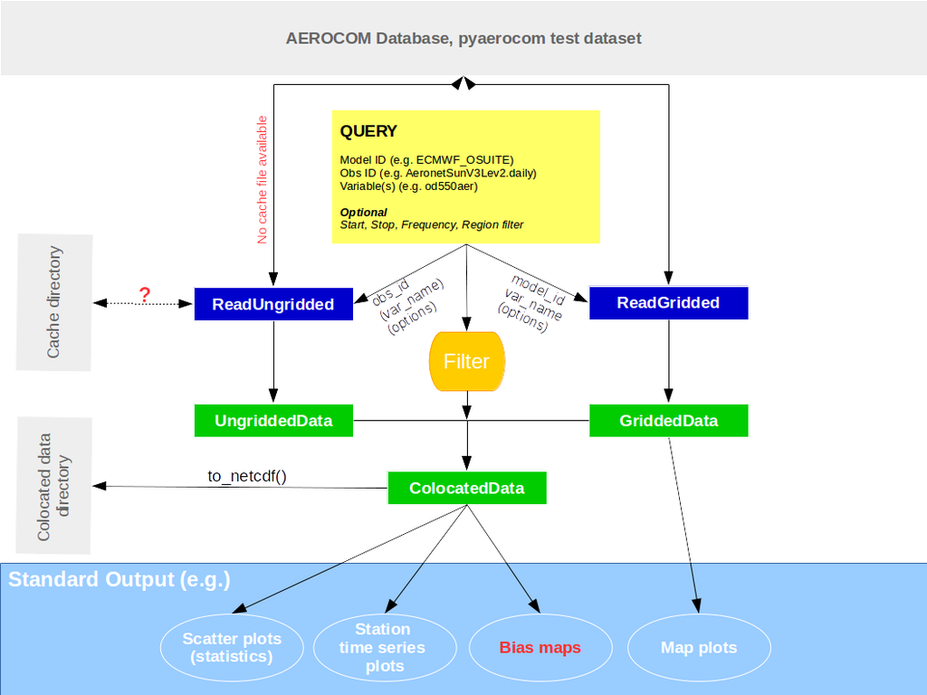

```python
show_flowchart()
```

#### Import pyaerocom

```python
import pyaerocom as pya
```

```
Initating pyaerocom configuration
Checking server configuration ...
Checking access to: /lustre/storeA
Access to lustre database: True
Init data paths for lustre
Expired time: 0.019 s
```

##### Check data directory

```python
pya.const.BASEDIR
```

```
'/lustre/storeA/project/aerocom'
```

#### Reading of and working with *gridded* model data (`ReadGridded` and `GriddedData` classes)

##### Find model data

```python
pya.browse_database('CAM53*-Oslo*PI*UNTUNED*')
```

```
Pyaerocom ReadGridded
---------------------
Model ID: CAM53-Oslo_7310_MG15CLM45_5feb2017IHK_53OSLO_PI_UNTUNED
Data directory: /lustre/storeA/project/aerocom/aerocom2/NorESM_SVN_TEST/CAM53-Oslo_7310_MG15CLM45_5feb2017IHK_53OSLO_PI_UNTUNED/renamed
Available variables: ['abs440aer', 'abs440aercs', 'abs500aer', 'abs5503Daer', 'abs550aer', 'abs550bc', 'abs550dryaer', 'abs550dust', 'abs550oa', 'abs550so4', 'abs550ss', 'abs670aer', 'abs870aer', 'airmass', 'area', 'asy3Daer', 'bc5503Daer', 'cheaqpso4', 'chegpso4', 'chepso2', 'cl3D', 'clt', 'drybc',…
Available years: [9999]
Available time resolutions ['monthly']
```

##### Variable information and conventions

```python
pya.const.VAR_PARAM.od550aer
```

```
Variable od550aer
Unit: 1
descriptions: Optical thickness at 550 nm
standard_name: atmosphere_optical_thickness_due_to_ambient_aerosol_particles
```

```python
pya.const.VAR_PARAM.scatc550gt1aer
```

```
Variable scatc550gt1aer
Unit: 1/Mm
descriptions: Aerosol light scattering coefficient at 550 nm (coarse mode)
standard_name: None
```

##### Read Aerosol optical depth at 550 nm (clear sky and all sky)

```python
reader = pya.io.ReadGridded('CAM53-Oslo_7310_MG15CLM45_5feb2017IHK_53OSLO_PD_UNTUNED')
print(reader)
```

```
Pyaerocom ReadGridded
---------------------
Model ID: CAM53-Oslo_7310_MG15CLM45_5feb2017IHK_53OSLO_PD_UNTUNED
Data directory: /lustre/storeA/project/aerocom/aerocom2/NorESM_SVN_TEST/CAM53-Oslo_7310_MG15CLM45_5feb2017IHK_53OSLO_PD_UNTUNED/renamed
Available variables: ['abs440aer', 'abs440aercs', 'abs500aer', 'abs5503Daer', 'abs550aer', 'abs550aercs', 'abs550bc', 'abs550dryaer', 'abs550dust', 'abs550oa', 'abs550so4', 'abs550ss', 'abs670aer', 'abs870aer', 'airmass', 'ang4487aer', 'ang4487csaer', 'area', 'asy3Daer', 'bc5503Daer', 'cheaqpso4', '…
Available years: [2004, 2005, 2006, 2007, 2008, 2009, 2010, 9999]
Available time resolutions ['monthly']
```

```python
od550aer = reader.read_var('od550aer')
od550aer
```

```
pyaerocom.GriddedData
Grid data: <iris 'Cube' of Aerosol optical depth at 500nm / (1) (time: 84; latitude: 192; longitude: 288)>
```

```python
od550csaer = reader.read_var('od550csaer')
od550csaer
```

```
pyaerocom.GriddedData
Grid data: <iris 'Cube' of Clear air Aerosol optical depth at 550nm / (1) (time: 84; latitude: 192; longitude: 288)>
```

##### Overview of what is in the data

```python
print(od550aer)
```

```
pyaerocom.GriddedData: CAM53-Oslo_7310_MG15CLM45_5feb2017IHK_53OSLO_PD_UNTUNED
Grid data: Aerosol optical depth at 500nm / (1) (time: 84; latitude: 192; longitude: 288)
     Dimension coordinates:
          time                            x             -               -
          latitude                        -             x               -
          longitude                       -             -               x
     Attributes:
          Conventions: CF-1.0
          NCO: 4.3.7
          Version: $Name$
          case: 53OSLO_PD_UNTUNED
          history: Thu Feb  9 11:05:21 2017: ncatted -O -a units,od550aer,o,c,1 /projects/NS2345K/CAM-Oslo/DO_AEROCOM/CAM53-Oslo_7310_MG15CLM45_5feb2017IHK_53OSLO_PD_UNTUNED/renamed/aerocom3_CAM53-Oslo_7310_MG15CLM45_5feb2017IHK_53OSLO_PD_UNTUNED_od550aer_Column_2004_monthly.nc
Thu...
          host: hexagon-2
          initial_file: /work/shared/noresm/inputdata/atm/cam/inic/fv/cami-mam3_0000-01-01_0.9...
          logname: ihkarset
          nco_openmp_thread_number: 1
          revision_Id: $Id$
          source: CAM
          title: UNSET
          topography_file: /work/shared/noresm/inputdata/noresm-only/inputForNudging/ERA_f09f09_3...
     Cell methods:
          mean: time
```

##### Access time stamps

```python
od550aer.time #in CF conventions
```

```
DimCoord(array([   0.,   31.,   60.,   91.,  121.,  152.,  182.,  213.,  244.,
        274.,  305.,  335.,  366.,  397.,  425.,  456.,  486.,  517.,
        547.,  578.,  609.,  639.,  670.,  700.,  731.,  762.,  790.,
        821.,  851.,  882.,  912.,  943.,  974., 1004., 1035., 1065.,
       1096., 1127., 1155., 1186., 1216., 1247., 1277., 1308., 1339.,
       1369., 1400., 1430., 1461., 1492., 1521., 1552., 1582., 1613.,
       1643., 1674., 1705., 1735., 1766., 1796., 1827., 1858., 1886.,
       1917., 1947., 1978., 2008., 2039., 2070., 2100., 2131., 2161.,
       2192., 2223., 2251., 2282., 2312., 2343., 2373., 2404., 2435.,
       2465., 2496., 2526.]), standard_name='time', units=Unit('days since 2004-01-01 00:00:00', calendar='gregorian'))
```

```python
od550aer.time_stamps()[0:3] # first 3, as numpy datetime64 objects
```

```
array(['2004-01-01T00:00:00.000000', '2004-02-01T00:00:00.000000',
       '2004-03-01T00:00:00.000000'], dtype='datetime64[us]')
```

##### Plotting maps

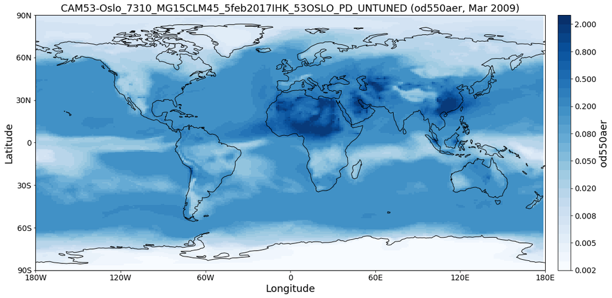

```python
fig1 = od550aer.quickplot_map('2009-3-15')
```

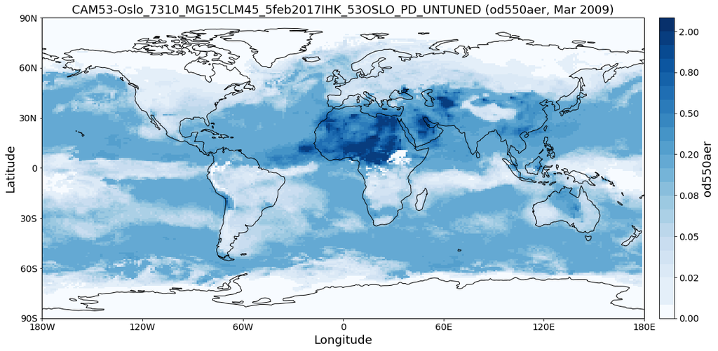

```python
fig2 = od550csaer.quickplot_map('2009-3-15')
```

##### Region filtering

```python
print(pya.region.get_all_default_region_ids())
```

```
['WORLD', 'EUROPE', 'ASIA', 'AUSTRALIA', 'CHINA', 'INDIA', 'NAFRICA', 'SAFRICA', 'SAMERICA', 'NAMERICA']
```

```python
print(pya.Region('EUROPE'))
```

```
pyaeorocom Region
Name: EUROPE
Longitude range: [-20, 70]
Latitude range: [30, 80]
Longitude range (plots): [-20, 70]
Latitude range (plots): [30, 80]
```

```python
f = pya.Filter('NAFRICA')
f
```

```
Filter([('_name', 'NAFRICA-wMOUNTAINS'),
        ('_region',
         Region NAFRICA Region([('_name', 'NAFRICA'), ('lon_range', [-20, 50]), ('lat_range', [0, 40]), ('lon_range_plot', [-20, 50]), ('lat_range_plot', [0, 40]), ('lon_ticks', None), ('lat_ticks', None)])),
        ('lon_range', [-20, 50]),
        ('lat_range', [0, 40]),
        ('alt_range', None)])
```

```python
od550aer_nafrica = f(od550aer)
```

```python
od550aer_nafrica
```

```
pyaerocom.GriddedData
Grid data: <iris 'Cube' of Aerosol optical depth at 500nm / (1) (time: 84; latitude: 42; longitude: 57)>
```

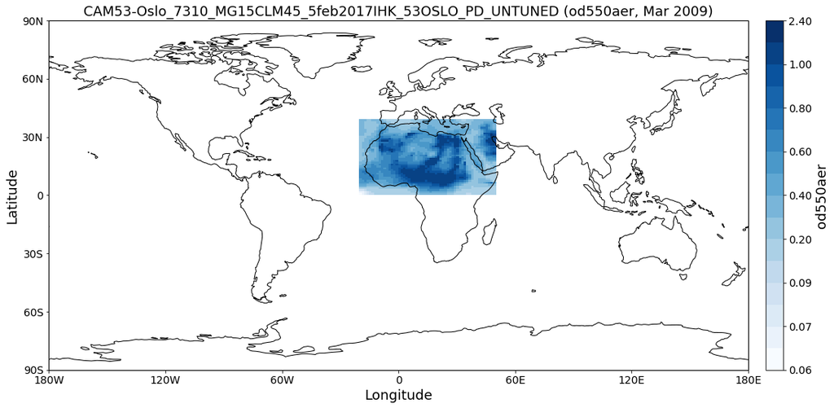

```python
ax1 = od550aer_nafrica.quickplot_map('2009-3-15')
```

##### Filtering of time

```python
od550aer_nafrica_2009 = od550aer_nafrica.crop(time_range=('1-1-2009', '31-12-2009'))
od550aer_nafrica_2009.time_stamps()
```

```
array(['2009-01-01T00:00:00.000000', '2009-02-01T00:00:00.000000',
       '2009-03-01T00:00:00.000000', '2009-04-01T00:00:00.000000',
       '2009-05-01T00:00:00.000000', '2009-06-01T00:00:00.000000',
       '2009-07-01T00:00:00.000000', '2009-08-01T00:00:00.000000',
       '2009-09-01T00:00:00.000000', '2009-10-01T00:00:00.000000',
       '2009-11-01T00:00:00.000000', '2009-12-01T00:00:00.000000'],
      dtype='datetime64[us]')
```

##### Data aggregation

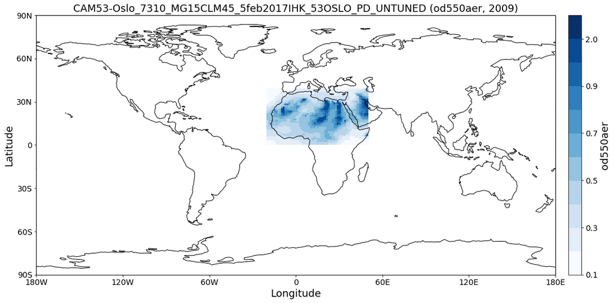

```python
od550aer_nafrica.downscale_time('yearly').quickplot_map('2009');
```

#### Reading of and working with ungridded data (`ReadUngridded` and `UngriddedData` classes)

```python
pya.const.CACHEDIR
```

```
'/home/jonasg/pyaerocom/_cache/jonasg'
```

```python
print('Caching is active? {}'.format(pya.const.CACHING))
```

```
Caching is active? True
```

##### Read Aeronet Sun v3 level 2 data

```python
pya.browse_database('Aeronet*V3*Lev2*daily')
```

```
Dataset name: AeronetSunV3Lev2.daily
Data directory: /lustre/storeA/project/aerocom/aerocom1/AEROCOM_OBSDATA/AeronetSunV3Lev2.0.daily/renamed
Supported variables: ['od340aer', 'od440aer', 'od500aer', 'od870aer', 'ang4487aer', 'ang4487aer_calc', 'od550aer']
Last revision: 20190311

Dataset name: AeronetSDAV3Lev2.daily
Data directory: /lustre/storeA/project/aerocom/aerocom1/AEROCOM_OBSDATA/Aeronet.SDA.V3L2.0.daily/renamed
Supported variables: ['od500gt1aer', 'od500lt1aer', 'od500aer', 'ang4487aer', 'od550aer', 'od550gt1aer', 'od550lt1aer']
Last revision: 20180928

Dataset name: AeronetInvV3Lev2.daily
Data directory: /lustre/storeA/project/aerocom/aerocom1/AEROCOM_OBSDATA/Aeronet.Inv.V3L2.0.daily/renamed
Supported variables: ['abs440aer', 'angabs4487aer', 'od440aer', 'ang4487aer', 'abs550aer', 'od550aer']
Last revision: 20180728
```

```python
obs_reader = pya.io.ReadUngridded('AeronetSunV3Lev2.daily')
print(obs_reader)
```

```
Dataset name: AeronetSunV3Lev2.daily
Data directory: /lustre/storeA/project/aerocom/aerocom1/AEROCOM_OBSDATA/AeronetSunV3Lev2.0.daily/renamed
Supported variables: ['od340aer', 'od440aer', 'od500aer', 'od870aer', 'ang4487aer', 'ang4487aer_calc', 'od550aer']
Last revision: 20190311
```

##### Read all timeseries of AOD from all AERONET stations

```python
aeronet_data = obs_reader.read(vars_to_retrieve='od550aer')
type(aeronet_data) #displays data type
```

```
Found Cache match for AeronetSunV3Lev2.daily
```

```
pyaerocom.ungriddeddata.UngriddedData
```

```python
aeronet_data
```

```
UngriddedData <networks: ['AeronetSunV3Lev2.daily']; vars: ['od550aer']; instruments: ['sun_photometer'];No. of stations: 1206
```

##### Plot all station coordinates

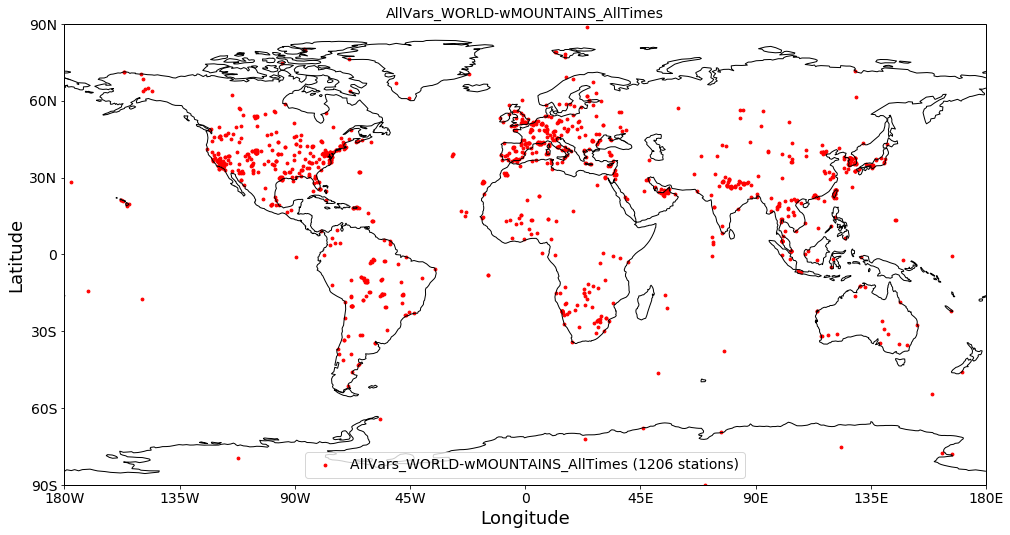

```python
aeronet_data.plot_station_coordinates();
```

##### Access of individual stations

```python
all_station_names = aeronet_data.unique_station_names
all_station_names[:10]  #displays first 10 stations
```

```
['AAOT',
 'AOE_Baotou',
 'ARM_Ascension_Is',
 'ARM_Barnstable_MA',
 'ARM_Darwin',
 'ARM_Gan_Island',
 'ARM_Graciosa',
 'ARM_Highlands_MA',
 'ARM_HyytialaFinland',
 'ARM_Macquarie_Is']
```

```python
station_data = aeronet_data['AOE_Baotou'] # this is fully equivalent with aeronet_data.to_station_data('AOE_Baotou')
type(station_data)
```

```
pyaerocom.stationdata.StationData
```

```python
print(station_data)
```

```
Pyaerocom StationData
---------------------
var_info (BrowseDict([('od550aer', OrderedDict([('unit', '1'), ('overlap', False), ('ts_type', 'daily')]))]))
   od550aer (<class 'collections.OrderedDict'>)
    unit: 1
    overlap: False
    ts_type: daily
station_coords ({'latitude': 40.851699999999994, 'longitude': 109.62879999999998, 'altitude': 1314.0})
   latitude: 40.851699999999994
   longitude: 109.62879999999998
   altitude: 1314.0
data_err (BrowseDict([('od550aer', array([nan, nan, nan, nan, nan, nan, nan, nan, nan, nan, nan, nan, nan,
       nan, nan, nan, nan, nan, nan, nan, nan, nan, nan, nan, nan, nan,
       nan, nan, nan, nan, nan]))]))
   od550aer (array, 31 items)
   [nan
    nan
    ...
    nan
    nan]

overlap:
filename: None
station_id: None
station_name: AOE_Baotou
instrument_name: sun_photometer
PI: Brent_Holben
country: None
ts_type: daily
latitude: 40.851699999999994
longitude: 109.62879999999998
altitude: 1314.0
data_id: AeronetSunV3Lev2.daily
dataset_name: None
data_product: None
data_version: None
data_level: None
revision_date: None
ts_type_src: daily
stat_merge_pref_attr: None
data_revision: 20190311

Data arrays
.................
dtime (array, 80 items)
   [numpy.datetime64('2013-09-25T00:00:00.000000000')
    numpy.datetime64('2013-09-26T00:00:00.000000000')
    ...
    numpy.datetime64('2013-12-12T00:00:00.000000000')
    numpy.datetime64('2013-12-13T00:00:00.000000000')]

Pandas Series
.................
od550aer (Series, 80 items)
```

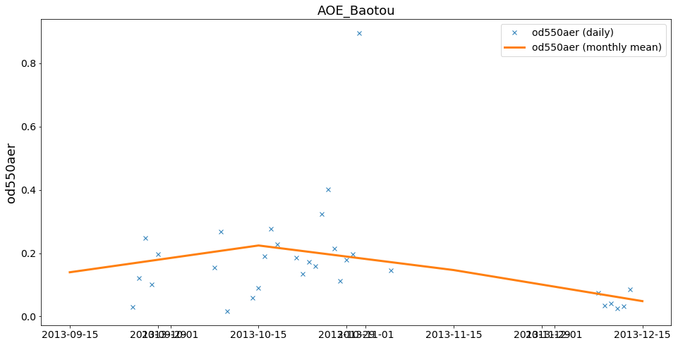

```python
ax = station_data.insert_nans_timeseries('od550aer').plot_timeseries('od550aer', marker='x', ls='none')
station_data.plot_timeseries('od550aer', freq='monthly', marker=' ', ls='-', lw=3, ax=ax)
```

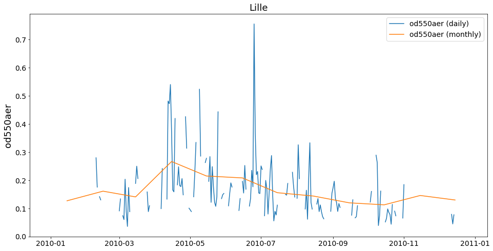

```python
ax=aeronet_data.to_station_data('Lille', start=2010, freq='daily').plot_timeseries('od550aer')
ax=aeronet_data.to_station_data('Lille', start=2010, freq='monthly').plot_timeseries('od550aer', ax=ax)
```

#### You can also plot the time-series directly from the `UngriddedData` object

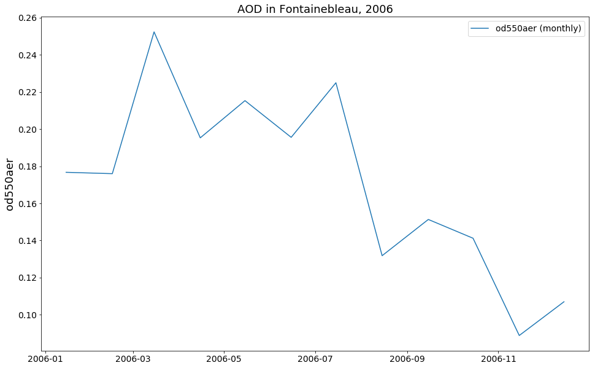

```python
aeronet_data.plot_station_timeseries('Fontainebleau', 'od550aer', ts_type='monthly',
                                     start=2006).set_title('AOD in Fontainebleau, 2006');
```

#### Colocation of model and obsdata

```python
col_all_sky_glob = pya.colocation.colocate_gridded_ungridded(od550aer, aeronet_data,
                                                                ts_type='monthly',
                                                                start=2010,
                                                                filter_name='WORLD-noMOUNTAINS')
type(col_all_sky_glob)
```

```
Interpolating data of shape (12, 192, 288). This may take a while.
Successfully interpolated cube
```

```
pyaerocom.colocateddata.ColocatedData
```

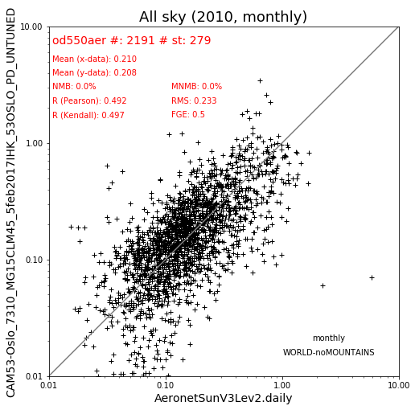

```python
ax1 = col_all_sky_glob.plot_scatter()
ax1.set_title('All sky (2010, monthly)');
```

##### Colocate region specific

```
Interpolating data of shape (12, 192, 288). This may take a while.
Successfully interpolated cube
```

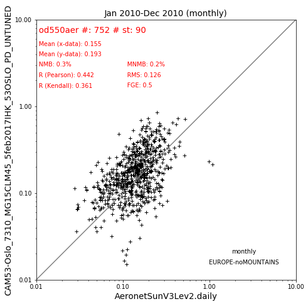

```python
pya.colocation.colocate_gridded_ungridded(od550aer, aeronet_data, ts_type='monthly',
                                          start=2010, filter_name='EUROPE-noMOUNTAINS').plot_scatter();
```

##### See what is in the ColocatedData object

```python
print(col_all_sky_glob)
```

```
Pyaerocom ColocatedData
-----------------------
Data: <xarray.DataArray 'od550aer' (data_source: 2, time: 12, station_name: 279)>
array([[[     nan, 0.117588, ...,      nan, 0.222138],
        [     nan, 0.132128, ...,      nan, 0.429762],
        ...,
        [0.132236, 0.195057, ...,      nan, 0.261765],
        [     nan, 0.098409, ...,      nan, 0.37905 ]],

       [[0.060114, 0.248935, ..., 0.066554, 0.335475],
        [0.099408, 0.370893, ..., 0.0616  , 0.468845],
        ...,
        [0.178814, 0.302825, ..., 0.07004 , 0.666344],
        [0.069544, 0.277792, ..., 0.039258, 0.469875]]])
Coordinates:
  * data_source   (data_source) <U55 'AeronetSunV3Lev2.daily' 'CAM53-Oslo_7310_MG15CLM45_5feb2017IHK_53OSLO_PD_UNTUNED'
    var_name      (data_source) <U8 'od550aer' 'od550aer'
    unit          (data_source) <U1 '1' '1'
    ts_type_src   (data_source) <U7 'daily' 'monthly'
  * time          (time) datetime64[ns] 2010-01-15 2010-02-15 ... 2010-12-15
  * station_name  (station_name) <U19 'ARM_Darwin' ... 'Zinder_Airport'
    latitude      (station_name) float64 -12.43 37.97 15.35 ... 32.64 13.78
    longitude     (station_name) float64 130.9 23.72 -1.479 ... -114.6 8.99
    altitude      (station_name) float64 29.9 130.0 305.0 ... 20.0 63.0 456.0
Attributes:
    data_source:   ['AeronetSunV3Lev2.daily', 'CAM53-Oslo_7310_MG15CLM45_5feb...
    var_name:      ['od550aer', 'od550aer']
    ts_type:       monthly
    filter_name:   WORLD-noMOUNTAINS
    ts_type_src:   ['daily', 'monthly']
    start_str:     20100101
    stop_str:      20101231
    unit:          ['1', '1']
    vert_scheme:   None
    data_level:    3
    revision_ref:  20190311
    region:        WORLD
    lon_range:     [-180, 180]
    lat_range:     [-90, 90]
    alt_range:     [-1000000.0, 1000.0]
```